# Sesgos de género en el SNI de CONACYT

Alejandro Reyes

El Sistema Nacional de Investigadores ([*SNI*](https://www.conacyt.gob.mx/index.php/el-conacyt/sistema-nacional-de-investigadores)), es un programa del Consejo Nacional de Ciencia y Tecnología de México ([*CONACYT*](http://conacyt.gob.mx/)) que tiene como objetivo reconocer el trabajo de las personas que se dedican a la ciencia en México. Como investigadores, nosotros aplicamos y podemos recibir distinciones que simbolizan la calidad y prestigio de nuestras contribuciones científicas. Las distinciones que podemos recibir son:

- Candidato a Investigador Nacional
- Investigador Nacional con tres niveles
- Investigador Emérito

Hace unos meses, escribí un blog post acerca de un análisis de [la brecha salarial de género en puestos académicos de la UNAM en el 2019](http://alejandroreyes.org/brecha-salarial-en-la-unam-en-el-2019/). Dudo que la Dra. Álvarez-Buylla, directora del *CONACYT*, haya leído mi blog post. Sin embargo, la Dra. Álvarez-Buylla escribió el día siguiente en twitter:

> Me preocupa mucho la brecha de género; este y otros problemas del Sistema Nacional de Investigadores deben corregirse. A 35 años de su creación, es momento de pensar colectivamente en su transformación virtuosa.  
> [#CienciaPorMéxico](https://twitter.com/hashtag/CienciaPorM%C3%A9xico?src=hash&ref_src=twsrc%5Etfw) [pic.twitter.com/j5tDP3SeE9](https://t.co/j5tDP3SeE9)

> — María Elena Álvarez-Buylla Roces (@ElenaBuylla) [December 11, 2019](https://twitter.com/ElenaBuylla/status/1204600047373094914?ref_src=twsrc%5Etfw)

Me llamó mucho la atención ese comentario al momento y me motivó a haver el análisis de este blog post. Me di a la tarea de explorar la gravedad de la situación a la que se refería la directora del *CONACYT* en su twit. Específicamente, me hice la pregunta: **¿Cómo se reflejan los sesgos de género en las distinciones del *SNI*?**

## Datos

En esta ocasión fue fácil conseguir los datos. En el portal de [datos abiertos del Gobierno de México](https://datos.gob.mx/), encontré una lista con los nombres de los investigadores y sus distinciones del *SNI* vigentes al año 2018. El código a continuación baja los datos del portal y usando el nombre de los investigadores, le asigna género a cada investigador con ayuda de un paquete de R llamado [*gender*](https://cran.r-project.org/web/packages/gender/index.html).

```r
fileName <- "Investigadores-SNI-Vigentes-2018.csv"
if(!file.exists( fileName )){
  download.file(
    "https://www.conacyt.gob.mx/datosabiertos/Investigadores-SNI-Vigentes-2018.csv",
             destfile=fileName )
}

dat <- read.csv( fileName, header=TRUE, fileEncoding="latin1" )
dat$primerNombre <- sapply( strsplit( as.character(dat$Nombre), " " ), "[[", 1 )

genderDf <- unique( gender( dat$primerNombre, 2012 ) )[,c("name", "gender")]
genderDf <- genderDf %>%
  dplyr::rename( primerNombre=name )

dat <- dplyr::left_join( dat, genderDf )
```

# Análisis

El gráfico a continuación presenta para cada distinción del *SNI* (eje $x$), el porcentage de individuos con esa distinción que son mujeres (eje $y$). El gráfico presenta los datos para cada área académica del *SNI*.

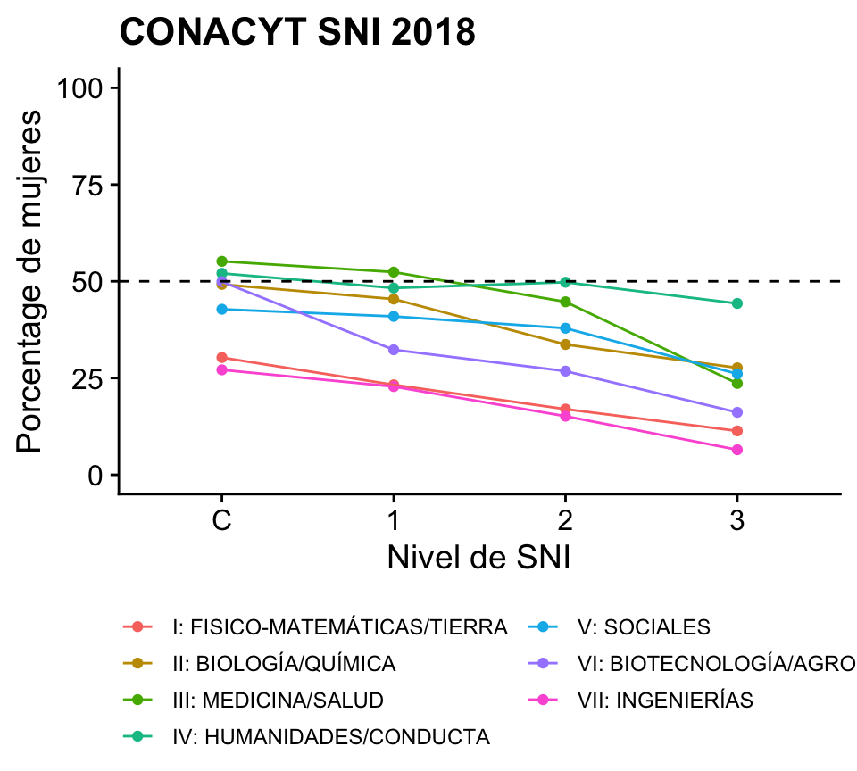

```r
dat$area <- gsub( "Área ", "", dat$`Área.del.Conocimiento`)
dat$area <- gsub("CIENCIAS |DE LA", "", dat$area)
dat$area <- gsub(" Y ", "/", dat$area)
dat$area <- gsub("/ ", "/", dat$area)
dat$area <- gsub("AGROPECUARIAS", "AGRO", dat$area)

dat <- dat %>%
  dplyr::select( gender, area, Nivel  ) %>%
  na.omit() %>%
  dplyr::group_by( area, Nivel ) %>%
  dplyr::summarise( males=sum( gender == "male" ),
                    females=sum( gender == "female"),
                    total=dplyr::n() ) %>%
  dplyr::mutate( percent_females=100*females/total )

dat$Nivel <- relevel( dat$Nivel, "C" )

dat %>%
  ggplot( aes( Nivel, percent_females, col=area, group=area ) ) +
  geom_point() +
  geom_line() +
  theme(legend.pos="bottom", legend.text=element_text(size=9)) +
  ylim(0, 100) +
  geom_hline(yintercept=50, col="#000000", linetype="dashed") +
  labs(y="Porcentage de mujeres", x="Nivel de SNI", col="", title="CONACYT SNI 2018") +
  guides(col=guide_legend(ncol=2))
```

*CONACYT* mandó un e-mail hace unos días diciendo que las convocatorias para ingreso y permanencia al *SNI* se abrirán en Febrero del 2020. **Ojalá que la comisión dictaminadora tenga una estrategia para reducir los sesgos de género del *SNI***.